# Coca-Cola Earnings

FIN 3380

# Set Working Directory

```r
setwd("C:/Users/siche/Documents/teaching/Introduction to Financial Data Analysis/L5")
library(dplyr)
library(tidyr)
```

## Step 1. Load the earnings eps.cola.RData and visualize the data

```r
load("eps.cola.RData")
head(eps.cola)
```

```
##      pends     value
## 1 19830331 -3.283414
## 2 19830630 -3.011862
## 3 19830930 -3.072613
## 4 19831231 -3.272804
## 5 19840331 -3.158251
## 6 19840630 -2.842153
```

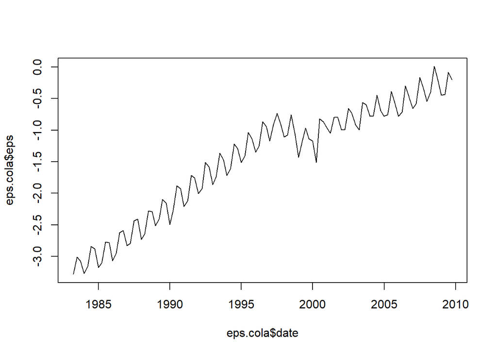

```r
eps.cola$pends = as.Date(as.character(eps.cola$pends),"%Y%m%d")
eps.cola = eps.cola %>% rename(eps = value,date = pends)
plot(eps.cola$eps~eps.cola$date,type='l')
```

#### The earnings exhibit a global trend and seasonality.

## Step 2. Take the first difference to detrend and take the seasonal difference.

#### Take the first difference in the series to detrend it $\Delta x_t = x_t-x_{t-1}$

```r
eps.cola = eps.cola %>% mutate(deps = eps-lag(eps,1)) %>% na.omit()
head(eps.cola)
```

```
##         date       eps        deps
## 2 1983-06-30 -3.011862  0.27155269
## 3 1983-09-30 -3.072613 -0.06075166
## 4 1983-12-31 -3.272804 -0.20019085
## 5 1984-03-31 -3.158251  0.11455296
## 6 1984-06-30 -2.842153  0.31609802
## 7 1984-09-30 -2.885981 -0.04382822
```

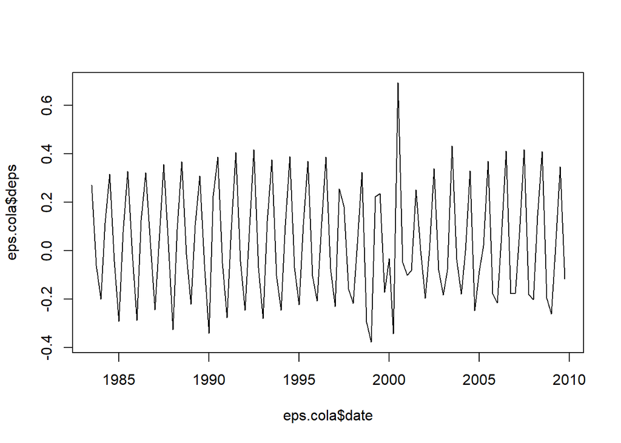

```r
plot(eps.cola$deps~eps.cola$date,type='l')
```

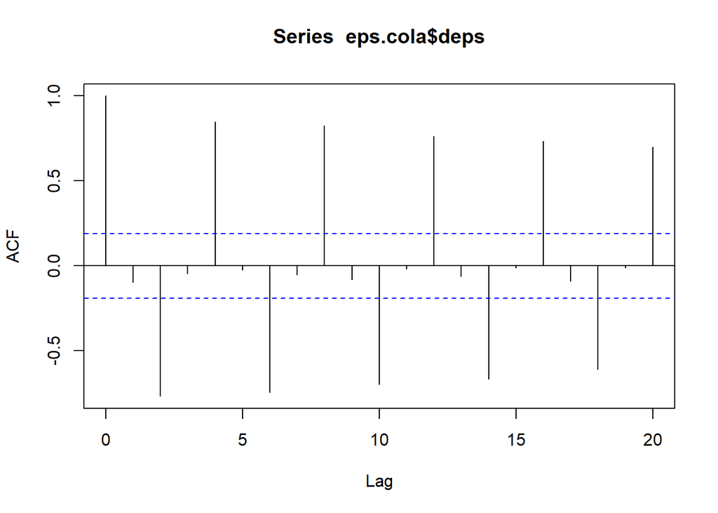

```r
acf(eps.cola$deps)
```

#### The difference $\Delta x_t$ still has strong seasonal pattern. The autocorrelations are large at lags, which are multiples of the periodicity 4. (To identify seasonality, use ACF rather than PACF)

#### Take a seasonal difference of $\Delta x_t$ to handle the strong seasonal pattern. $\Delta x_t - \Delta x_{t-4}$

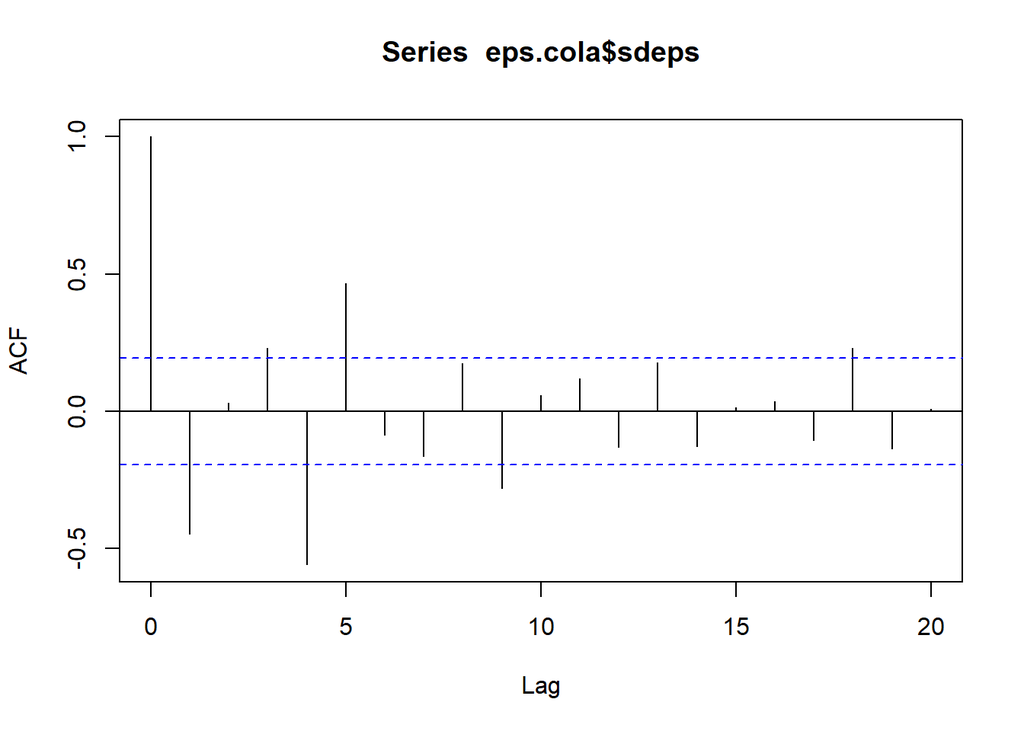

```r
eps.cola = eps.cola %>% mutate(sdeps = deps-lag(deps,4)) %>% na.omit()
acf(eps.cola$sdeps)
```

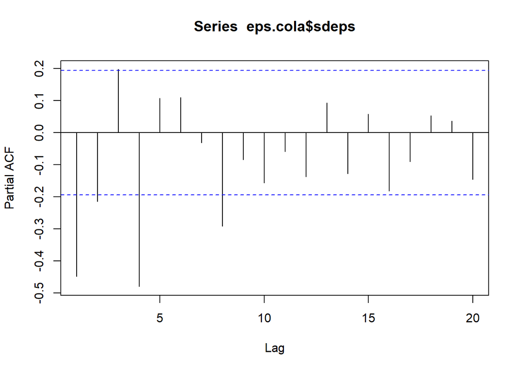

```r
pacf(eps.cola$sdeps)
```

#### 5. Non-seasonal behavior: The ACF has a spike at lag 1 and a marginal spike at lag 3,indicting a regular MA(1).

## Step 3. Estimate the ARIMA model with seasonality

#### With in the seasonal part, we include the I(1) as regular process to indicate seasonality exist.

```r
m1 = arima(eps.cola$eps,order=c(0,1,1),
           seasonal=list(order=c(0,1,1),period=4))
m1
```

```
##
## Call:
## arima(x = eps.cola$eps, order = c(0, 1, 1), seasonal = list(order = c(0, 1,
##     1), period = 4))
##
## Coefficients:
##           ma1     sma1
##       -0.4081  -0.8133
## s.e.   0.0885   0.0759
##
## sigma^2 estimated as 0.007495:  log likelihood = 97.42,  aic = -188.84
```

## Step 4. Model checking

```r
Box.test(m1$residuals,lag=12,type="Ljung")
```

```
##
##  Box-Ljung test
##
## data:  m1$residuals
## X-squared = 13.225, df = 12, p-value = 0.3529
```

## Step 5. Out-of-sample forecasting

```r
m1 = arima(eps.cola$eps[1:90],order=c(0,1,1),
           seasonal=list(order=c(0,1,1),period=4))
m1
```

```
##
## Call:
## arima(x = eps.cola$eps[1:90], order = c(0, 1, 1), seasonal = list(order = c(0,
##     1, 1), period = 4))
##
## Coefficients:
##           ma1     sma1
##       -0.4205  -0.7993
## s.e.   0.0916   0.0773
##
## sigma^2 estimated as 0.00807:  log likelihood = 82.06,  aic = -158.13
```

```r
pm1 = predict(m1,7)
names(pm1)
```

```
## [1] "pred" "se"
```

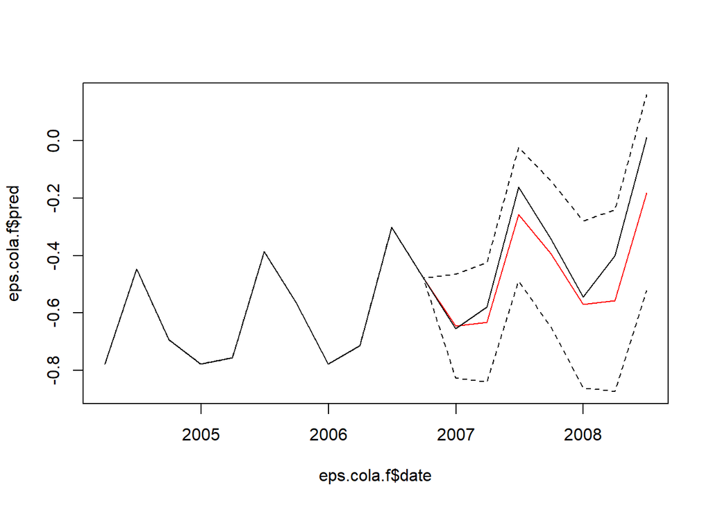

```r
pred = pm1$pred
se = pm1$se
eps.cola.f = eps.cola[1:97,]
eps.cola.f = eps.cola.f %>%
  mutate(pred = eps,
         up = eps,
         bt = eps)
eps.cola.f$pred[91:97]=pred
eps.cola.f$up[91:97]=pred+2*se
eps.cola.f$bt[91:97]=pred-2*se
eps.cola.f = eps.cola.f[80:nrow(eps.cola.f),]

yr = range(eps.cola.f[,c("eps","up","bt")])
plot(eps.cola.f$pred~eps.cola.f$date,type='l',col='red',ylim=yr)
lines(eps.cola.f$up~eps.cola.f$date,lty=2)
lines(eps.cola.f$bt~eps.cola.f$date,lty=2)
lines(eps.cola.f$eps~eps.cola.f$date)
```